# Il progetto, perchè è nato e obbiettivo:

- È nato al Contamination Lab, realizzato dall'università di Udine
- Analisi dell'umidità del terreno dati dei fattori esterni
- Creazione di un algoritmo predittivo per gli anni sucessivi

# I datasets

- Piattaforma ufficiale federale DWD: dati stazioni meteo
- Archivi NASA: i dati satellitari
- BGR, Istituto federale di geoscienze e risorse naturali: i dati geologici

# Raccolta e organizzazione CSV delle stazioni meteo

A seguito analizzeremo ed eseguiremo nel dettaglio i passaggi per individuare, scaricare e organizzare oppurtunamente i datasets inerenti alle stazioni meteo.

## Rappresentazione delle stazioni meteo

Per comprendere meglio la disposizione delle stazioni meteo, vengono rappresentate tre mappe, la prima con le stazioni totali, la seconda dove vengono segnalate le stazioni non attive nel periodo selezionato, nella terza solo le stazioni attive nel periodo

Sono presenti 1376 colonnine meteo totali.

Make this Notebook Trusted to load map: File -> Trust Notebook

[interactive chart not shown]

## Confronto colonnine meteo

Vengono evidenziate ora in rosso le stazioni meteo che non sono attive nel periodo selezionato (anno 2020), nelle analisi sucessive verranno escluse per risparmiare dati e rendere l'analisi più semplice.

Make this Notebook Trusted to load map: File -> Trust Notebook

[interactive chart not shown]

## Stazioni meteo selezionate

A seguito, la locazione delle stazioni meteo in Germania attive nel 2020.

Make this Notebook Trusted to load map: File -> Trust Notebook

[interactive chart not shown]

**Sono presenti:** 575 colonnine meteo attive nel 2020.

## Il nuovo dataset "pulito"

Dopo l'opportuna elaborazione, rispetto al dataset iniziale sono presenti circa 800 stazioni meteo in meno che non sarebbero state utilizzate nell'analisi dei dati, in quanto attive in un periodo temporale diverso da quello analizzato.

## Data scraping

Vista il gran numero di dataset da scaricare [dal sito](https://opendata.dwd.de/climate_environment/CDC/observations_germany/climate/daily/kl/historical/), è opportuno scrivere uno script per automatizzare il processo e salvare localmente i files in base al CSV precedentemente realizzato.

## Analisi della struttura dei datasets

Il sito a cui abbiamo fatto riferimento precedentemente mette a disposizione un [file pdf](https://opendata.dwd.de/climate_environment/CDC/observations_germany/climate/daily/kl/DESCRIPTION_obsgermany-climate-daily-kl_en.pdf) per interpretare i dati in maniera corretta.

## Organizzazione dei dati in un unico CSV

Per poter lavorare su un unico file invece che con una moltiduine di files frammentati, è opportuno raccogliere gli oltre 500 csv in un unico elemento.

## Ulteriore pulizia del dataset

Dopo aver organizzato in un unico file i dati, rimuoviamo tutti quelli non inerenti all'arco di tempo da noi selezionato in modo da ridurre ulteriormente la quantità di dati con cui è necessario lavorare:

## Assegnare coordinate

Assegnamo le coordinate al dataset per geolocalozzare le colonne meteo sucessivamente.

# Dataset della NASA e files .h5

La NASA mette a disposizione del pubblico diversi datasets, da cui abbiamo attinto per questo progetto.

## Conversione files .h5 in CSV

I files .h5 (ampliamente usati dalla NASA) consentono di raggruppare una enorme mole di dati con eccellenti rapporti di compressione in un unico file, per il nostro obbiettivo, tuttavia, è necessaria solo una parte di queste informazioni.

Il seguente codice consente di esplorare i file .h5 e creare CSV da essi e raggrupparli in un unica cartella per alleggerire notevolemente il peso comuptazionale sul PC.

Per una spiegazione più dettagliata consiglio di visualizzare il file introduzione_a_h5pyfiles.ipynb.

## Ripetizione per i dati pomeridiani

All'interno dei dataset, le rilevazioni pomeridiane sono distinte. Viene ripetuto il processo di prima creando una seconda cartella con i dati presenti nel pomeriggio.

## Unione dei datasets

Il seguente codice le unisce dei valori del mattino e del pomeriggio e esegue la media qualora sia presente più di un dato per il medesimo punto geografico.

[figure not shown]

## Visualizziamo la mappa della Germania

Ripetiamo il processo precedemente effettuato per plottare la mappa della Germania invece del mondo intero per avere una più chiara visione dei dati.

[figure not shown]

## Controlliamo la geometria senza il dataset di supporto

Non avendo chiari valori e legenda ci limitiamo a mappare la struttura per essere sicuri di avere tutte le aree necessarie e salviamo la mappa per eventuali scopi futuri.

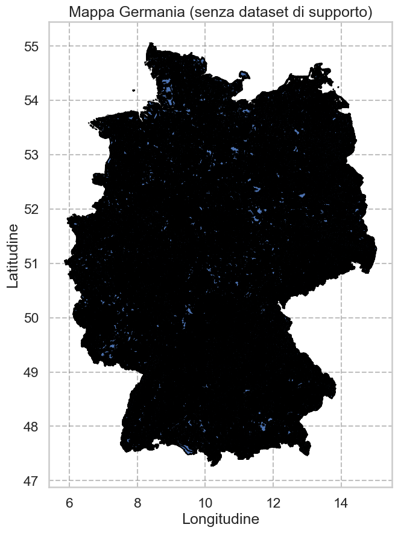

## Uniamo il dataset e il dataset di supporto

Dopo aver esportato i CSV necessari dal archivio originale, li possiamo unire con il dataset predecentemente realizzato per ottenere una legenda e assegnare dei valori concreti ai vari punti.

[figure not shown]

[figure not shown]

# Analisi dati

Eseguamo ora una iniziale analisi dei dati per determinarne la quantià, proprietà e simili.

## Osservazioni generali sull'umidità del terrno

Possiamo ora vedere quale sia la distribuzione dell'umidità del terreno nel corso di un anno.

I valori riportati sono la quantià che un determinato valore (o un valore approssimato ad esso) compare all'interno del dataset.

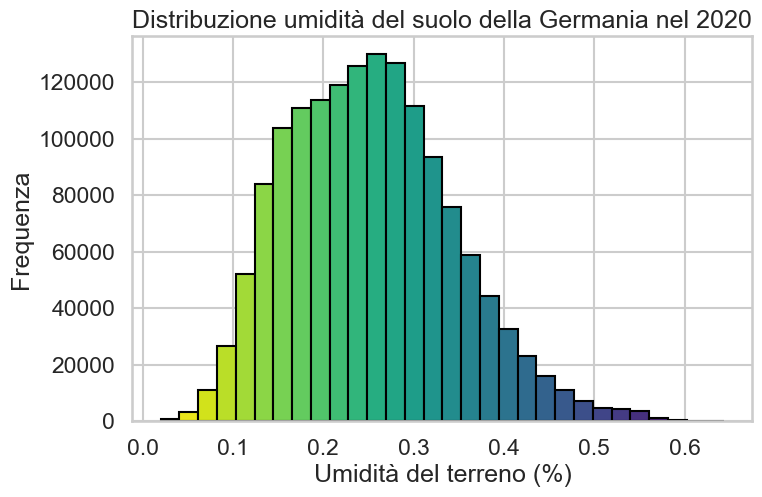

## Controllo per ogni mese

Vengono ora controllati i valori per ogni singolo mese. Con buona probabilità si troveranno dei mesi con una mediana più bassa (e quindi più secchi) di altri.

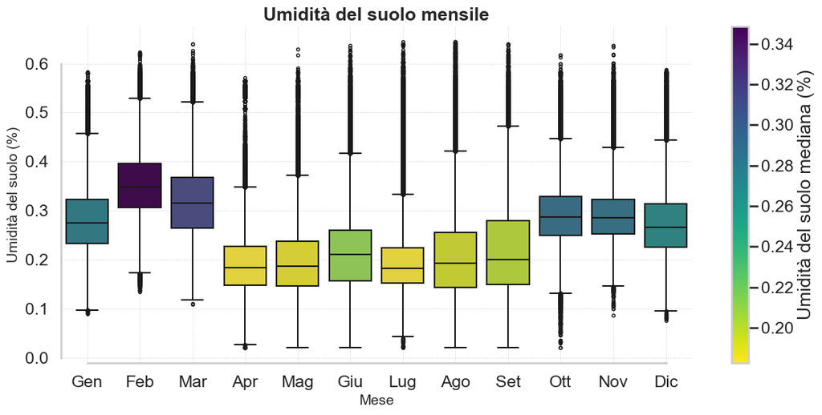

## Distribuzione dei terreni

Analizziamo ora la distribuzione dei terreni in Germania in base alla superficie da loro occupati.

I terreni che non hanno un tag sono indicati con "Sconosciuto", seppur ricoprono una minima percentuale (attorno al 1%), mi è parso opportuno rappresentarli lo stesso sul grafico.

Per facilitare la visualizzazione del grafico, ho raccolto tutti i valori inferiori allo 0.5% in un unica categoria "altro" e li ho rappresentati poi come ultimo valore.

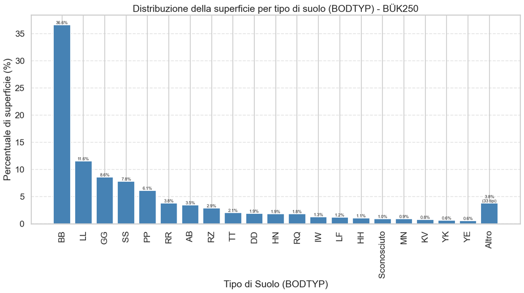

## Stazioni Meteo

Iniziamo ora ad analizzare i dati delle stazioni meteo.

Realizzeremo dei grafici in maniera automatizzata dei valori rilevanti all'interno del dataset.

I grafici vengono realizzati con la palette "viridis_r" per una scelta stilistica.

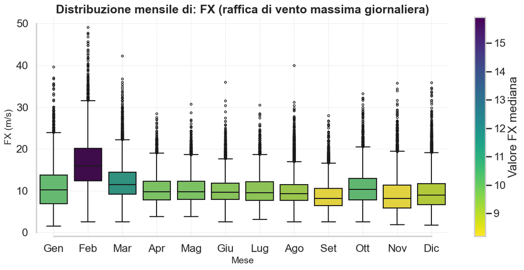

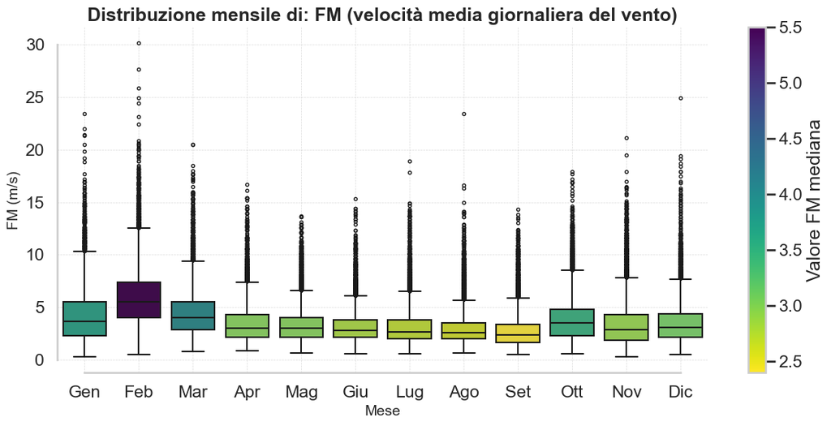

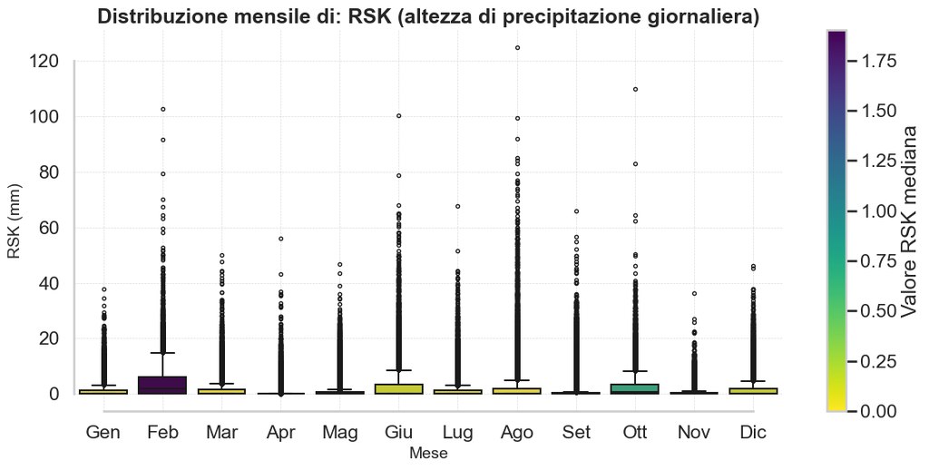

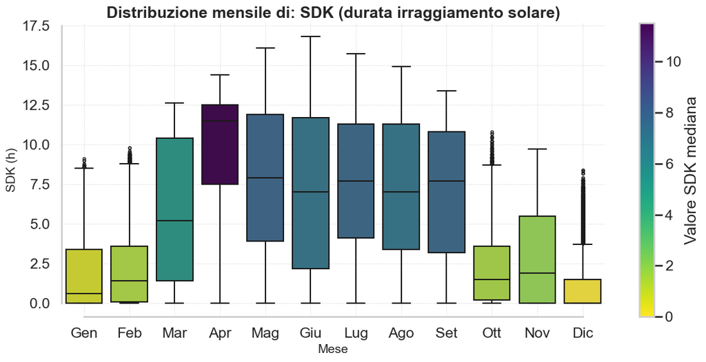

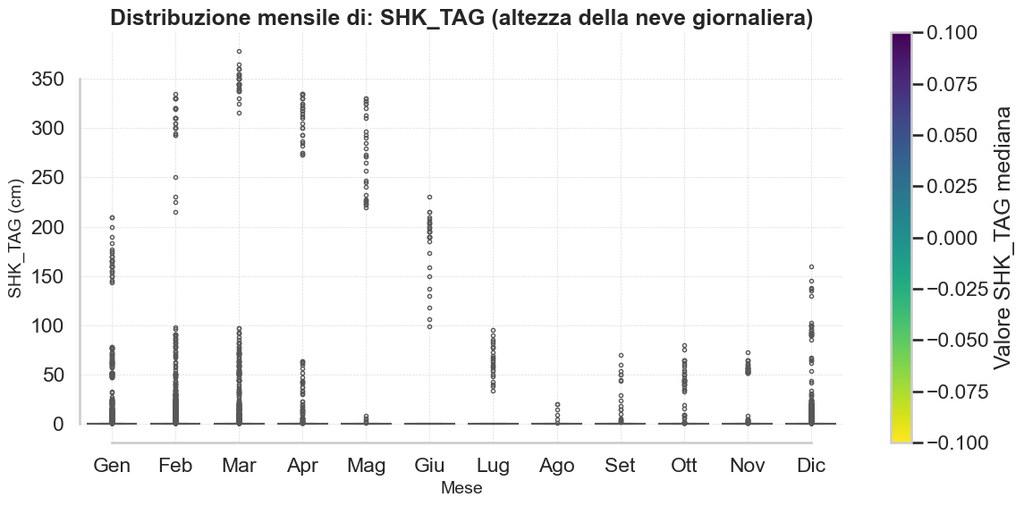

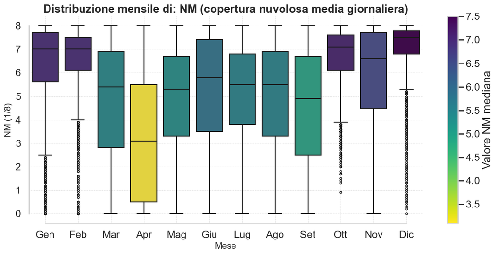

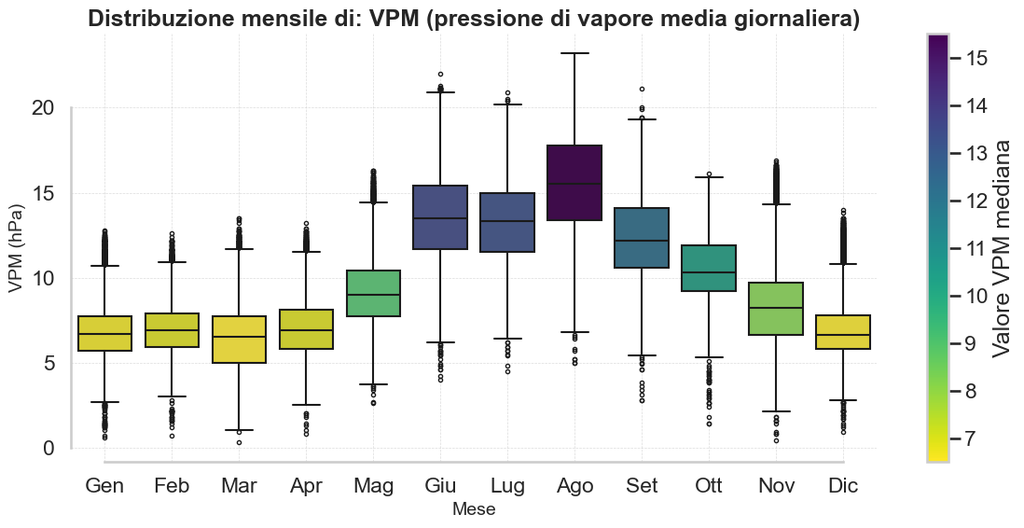

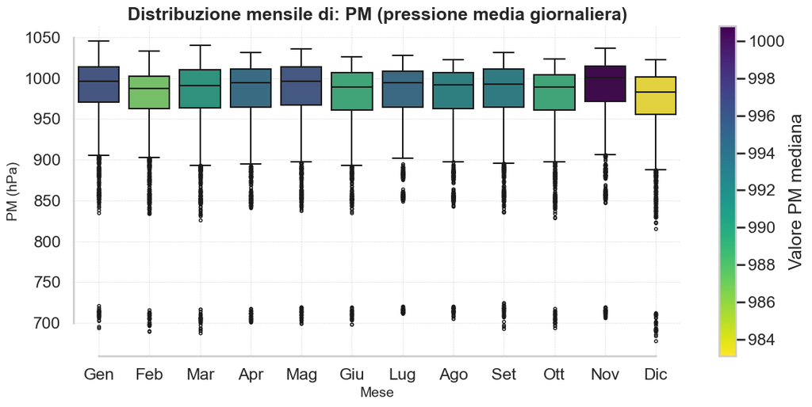

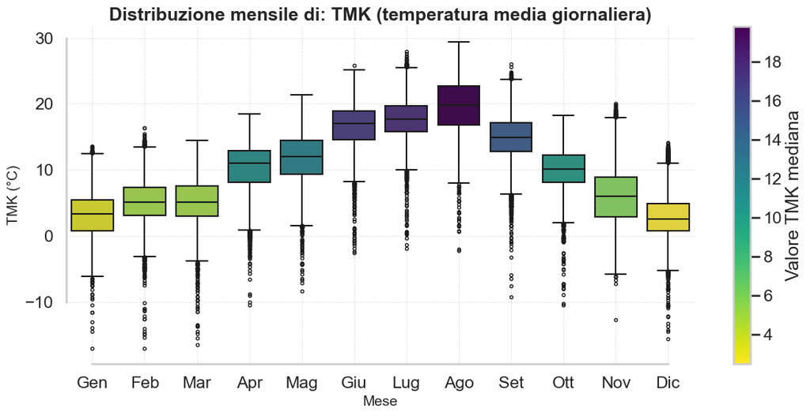

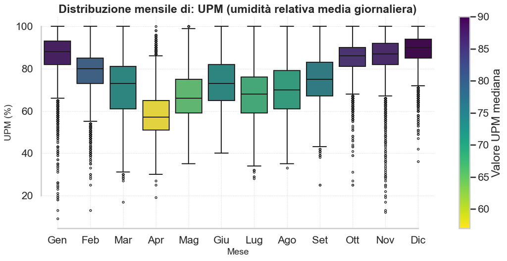

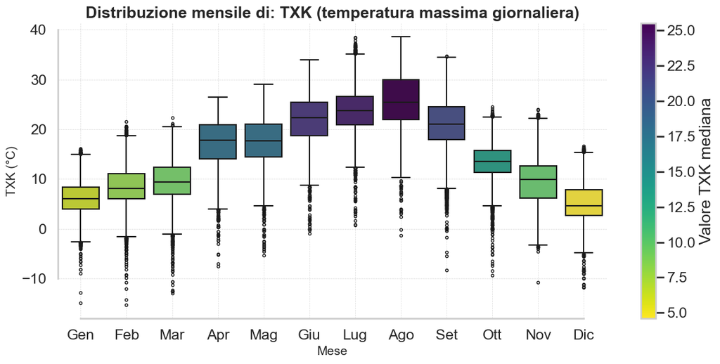

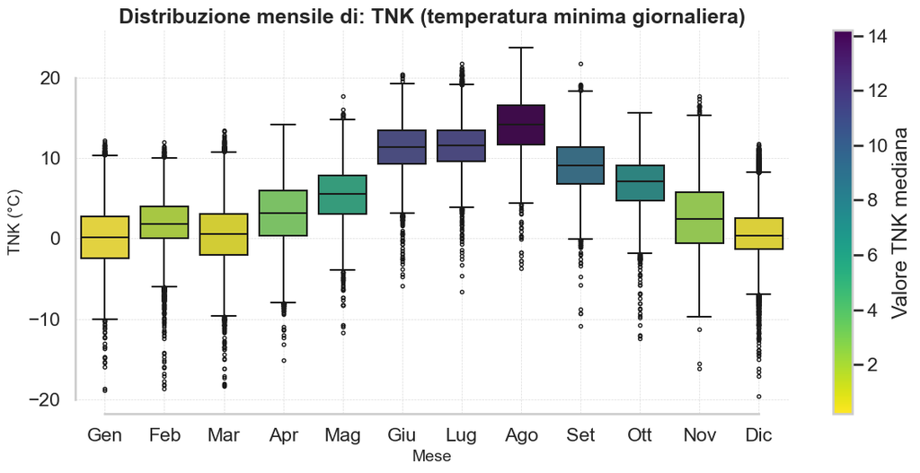

[1 more figures not shown]

## Visualizzazione delle distanze

Per poter avere una rappresentazione grafica della distanza dalle colonnine, la "griglia" dei valori di umidità viene colorata in base alla distanza dalla stazione meteo più vicina.

Make this Notebook Trusted to load map: File -> Trust Notebook

[interactive chart not shown]

## Cerchiamo delle correlazioni

Per determinare eventuali correlazioni tra i tipi di terreno e l'umidità del suolo, mi sono servito del metodo standard e del metodo con dei pesi.

Viene generato il grafico con entrambi; i pesi sono stati scelti in maniera tale da rendere meno rilevanti i valori dell'umidità, all'interno della correlazione, con il progressivo allontanarsi dalle stazioni meteo. è stato scelto un valore di 20 km come valore massimo consentito per essere preso in cosiderazione nella media pesata.

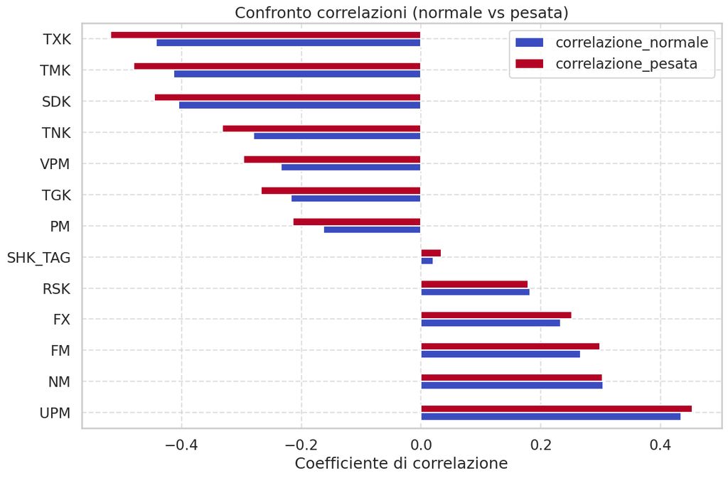

## Correlazione a distanza di giorni

Viene ora analizzata la correlazione a seguito di lag, ovvero come una correlazione si comporta qualora si tenga conto anche dei valori precedenti o antecedenti ad essa, proprietà da tenere in considerazione trattandosi di fenomeni le cui ripercussioni si possono protrarre nel tempo.

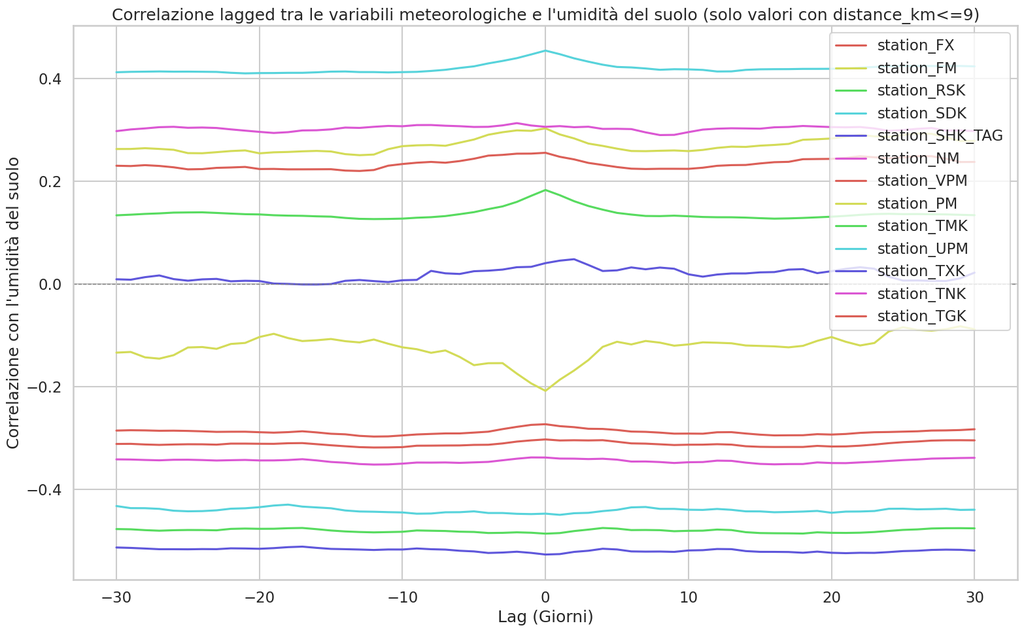

## Generazione di un grafico

Visualizziamo meglio i dati disponendoli in un boxplot, eventuali correlazioni tra tipologia di terreno e umidità media dovrebbero emergere da questa analisi.

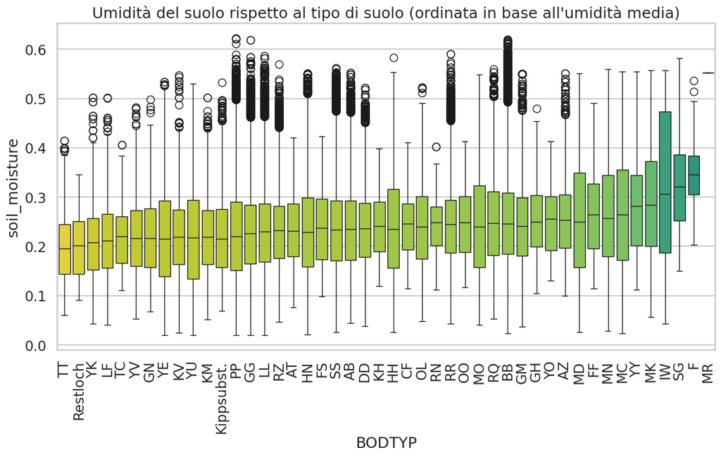

# Considerazioni finali

Sono presenti molteplici correlazioni, alcune più debole di altre

Per i dati meteo le correlazioni sono più evidenti, e si notano delle influenze anche tenendo conto dei giorni precedenti

Per le tipoligie di terreno invece, vi sono presenti delle corellazioni, anche se più attenuate

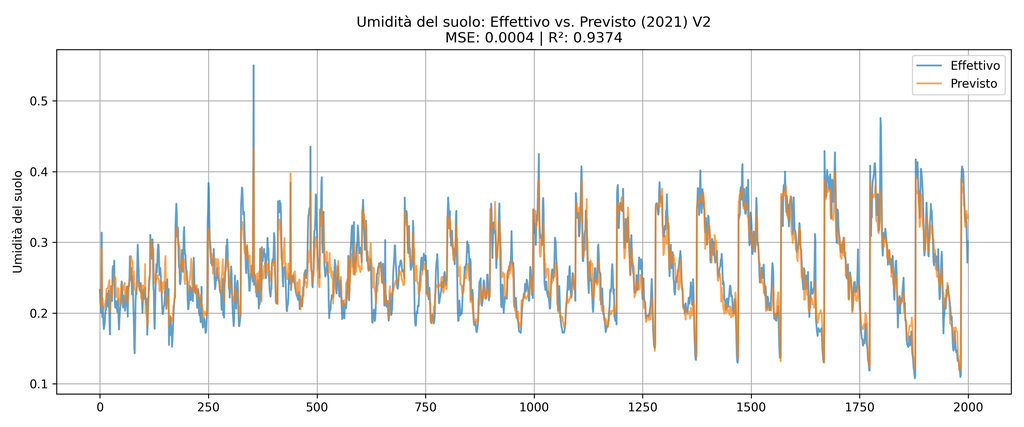